# Risk Factor Analysis

## Outcome Variable

**Outcome Variable:** ever_stunted

## Predictor Variables

**Intervention Variable:** nrooms

**Adjustment Set:**

unadjusted

## Stratifying Variables

The analysis was stratified on these variable(s):

- agecat
- studyid
- country

## Data Summary

| agecat | studyid | country | A | n | nA | nAY0 | nAY1 |
| --- | --- | --- | --- | --- | --- | --- | --- |
| 3 months | ki0047075b-MAL-ED | BANGLADESH | 1 | 242 | 152 | 107 | 45 |
| 3 months | ki0047075b-MAL-ED | BANGLADESH | 2 | 242 | 50 | 37 | 13 |
| 3 months | ki0047075b-MAL-ED | BANGLADESH | 3 | 242 | 28 | 22 | 6 |
| 3 months | ki0047075b-MAL-ED | BANGLADESH | 4+ | 242 | 12 | 11 | 1 |
| 3 months | ki0047075b-MAL-ED | BRAZIL | 1 | 210 | 4 | 4 | 0 |
| 3 months | ki0047075b-MAL-ED | BRAZIL | 2 | 210 | 20 | 16 | 4 |
| 3 months | ki0047075b-MAL-ED | BRAZIL | 3 | 210 | 59 | 49 | 10 |
| 3 months | ki0047075b-MAL-ED | BRAZIL | 4+ | 210 | 127 | 108 | 19 |
| 3 months | ki0047075b-MAL-ED | INDIA | 1 | 235 | 84 | 62 | 22 |
| 3 months | ki0047075b-MAL-ED | INDIA | 2 | 235 | 78 | 50 | 28 |
| 3 months | ki0047075b-MAL-ED | INDIA | 3 | 235 | 48 | 38 | 10 |
| 3 months | ki0047075b-MAL-ED | INDIA | 4+ | 235 | 25 | 22 | 3 |
| 3 months | ki0047075b-MAL-ED | NEPAL | 1 | 236 | 52 | 43 | 9 |
| 3 months | ki0047075b-MAL-ED | NEPAL | 2 | 236 | 31 | 28 | 3 |
| 3 months | ki0047075b-MAL-ED | NEPAL | 3 | 236 | 22 | 17 | 5 |
| 3 months | ki0047075b-MAL-ED | NEPAL | 4+ | 236 | 131 | 112 | 19 |
| 3 months | ki0047075b-MAL-ED | PERU | 1 | 272 | 19 | 9 | 10 |
| 3 months | ki0047075b-MAL-ED | PERU | 2 | 272 | 52 | 34 | 18 |
| 3 months | ki0047075b-MAL-ED | PERU | 3 | 272 | 62 | 41 | 21 |
| 3 months | ki0047075b-MAL-ED | PERU | 4+ | 272 | 139 | 94 | 45 |
| 3 months | ki0047075b-MAL-ED | SOUTH AFRICA | 1 | 257 | 14 | 12 | 2 |
| 3 months | ki0047075b-MAL-ED | SOUTH AFRICA | 2 | 257 | 22 | 16 | 6 |
| 3 months | ki0047075b-MAL-ED | SOUTH AFRICA | 3 | 257 | 25 | 18 | 7 |
| 3 months | ki0047075b-MAL-ED | SOUTH AFRICA | 4+ | 257 | 196 | 141 | 55 |
| 3 months | ki0047075b-MAL-ED | TANZANIA, UNITED REPUBLIC OF | 1 | 250 | 13 | 9 | 4 |
| 3 months | ki0047075b-MAL-ED | TANZANIA, UNITED REPUBLIC OF | 2 | 250 | 63 | 44 | 19 |
| 3 months | ki0047075b-MAL-ED | TANZANIA, UNITED REPUBLIC OF | 3 | 250 | 66 | 51 | 15 |
| 3 months | ki0047075b-MAL-ED | TANZANIA, UNITED REPUBLIC OF | 4+ | 250 | 108 | 70 | 38 |
| 3 months | ki1000108-CMC-V-BCS-2002 | INDIA | 1 | 362 | 196 | 128 | 68 |
| 3 months | ki1000108-CMC-V-BCS-2002 | INDIA | 2 | 362 | 101 | 63 | 38 |

[output cut: 278 more lines]

The following strata were considered:

- agecat: 12 months, studyid: ki0047075b-MAL-ED, country: BANGLADESH
- agecat: 12 months, studyid: ki0047075b-MAL-ED, country: BRAZIL
- agecat: 12 months, studyid: ki0047075b-MAL-ED, country: INDIA
- agecat: 12 months, studyid: ki0047075b-MAL-ED, country: NEPAL
- agecat: 12 months, studyid: ki0047075b-MAL-ED, country: PERU
- agecat: 12 months, studyid: ki0047075b-MAL-ED, country: SOUTH AFRICA
- agecat: 12 months, studyid: ki0047075b-MAL-ED, country: TANZANIA, UNITED REPUBLIC OF
- agecat: 12 months, studyid: ki1000108-CMC-V-BCS-2002, country: INDIA
- agecat: 12 months, studyid: ki1000108-IRC, country: INDIA
- agecat: 12 months, studyid: ki1017093b-PROVIDE, country: BANGLADESH
- agecat: 12 months, studyid: ki1017093c-NIH-Crypto, country: BANGLADESH
- agecat: 12 months, studyid: ki1113344-GMS-Nepal, country: NEPAL
- agecat: 12 months, studyid: ki1114097-CONTENT, country: PERU
- agecat: 12 months, studyid: ki1135781-COHORTS, country: INDIA
- agecat: 12 months, studyid: kiGH5241-JiVitA-3, country: BANGLADESH
- agecat: 12 months, studyid: kiGH5241-JiVitA-4, country: BANGLADESH
- agecat: 18 months, studyid: ki0047075b-MAL-ED, country: BANGLADESH
- agecat: 18 months, studyid: ki0047075b-MAL-ED, country: BRAZIL
- agecat: 18 months, studyid: ki0047075b-MAL-ED, country: INDIA
- agecat: 18 months, studyid: ki0047075b-MAL-ED, country: NEPAL
- agecat: 18 months, studyid: ki0047075b-MAL-ED, country: PERU
- agecat: 18 months, studyid: ki0047075b-MAL-ED, country: SOUTH AFRICA
- agecat: 18 months, studyid: ki0047075b-MAL-ED, country: TANZANIA, UNITED REPUBLIC OF
- agecat: 18 months, studyid: ki1000108-CMC-V-BCS-2002, country: INDIA
- agecat: 18 months, studyid: ki1000108-IRC, country: INDIA
- agecat: 18 months, studyid: ki1017093b-PROVIDE, country: BANGLADESH
- agecat: 18 months, studyid: ki1017093c-NIH-Crypto, country: BANGLADESH
- agecat: 18 months, studyid: ki1113344-GMS-Nepal, country: NEPAL
- agecat: 18 months, studyid: ki1114097-CONTENT, country: PERU
- agecat: 18 months, studyid: kiGH5241-JiVitA-3, country: BANGLADESH
- agecat: 18 months, studyid: kiGH5241-JiVitA-4, country: BANGLADESH
- agecat: 24 months, studyid: ki0047075b-MAL-ED, country: BANGLADESH
- agecat: 24 months, studyid: ki0047075b-MAL-ED, country: BRAZIL
- agecat: 24 months, studyid: ki0047075b-MAL-ED, country: INDIA
- agecat: 24 months, studyid: ki0047075b-MAL-ED, country: NEPAL
- agecat: 24 months, studyid: ki0047075b-MAL-ED, country: PERU
- agecat: 24 months, studyid: ki0047075b-MAL-ED, country: SOUTH AFRICA
- agecat: 24 months, studyid: ki0047075b-MAL-ED, country: TANZANIA, UNITED REPUBLIC OF
- agecat: 24 months, studyid: ki1000108-CMC-V-BCS-2002, country: INDIA
- agecat: 24 months, studyid: ki1000108-IRC, country: INDIA
- agecat: 24 months, studyid: ki1017093b-PROVIDE, country: BANGLADESH
- agecat: 24 months, studyid: ki1017093c-NIH-Crypto, country: BANGLADESH
- agecat: 24 months, studyid: ki1113344-GMS-Nepal, country: NEPAL
- agecat: 24 months, studyid: ki1114097-CONTENT, country: PERU
- agecat: 24 months, studyid: kiGH5241-JiVitA-3, country: BANGLADESH
- agecat: 24 months, studyid: kiGH5241-JiVitA-4, country: BANGLADESH
- agecat: 3 months, studyid: ki0047075b-MAL-ED, country: BANGLADESH
- agecat: 3 months, studyid: ki0047075b-MAL-ED, country: BRAZIL
- agecat: 3 months, studyid: ki0047075b-MAL-ED, country: INDIA
- agecat: 3 months, studyid: ki0047075b-MAL-ED, country: NEPAL
- agecat: 3 months, studyid: ki0047075b-MAL-ED, country: PERU
- agecat: 3 months, studyid: ki0047075b-MAL-ED, country: SOUTH AFRICA
- agecat: 3 months, studyid: ki0047075b-MAL-ED, country: TANZANIA, UNITED REPUBLIC OF
- agecat: 3 months, studyid: ki1000108-CMC-V-BCS-2002, country: INDIA
- agecat: 3 months, studyid: ki1000108-IRC, country: INDIA
- agecat: 3 months, studyid: ki1017093b-PROVIDE, country: BANGLADESH
- agecat: 3 months, studyid: ki1017093c-NIH-Crypto, country: BANGLADESH
- agecat: 3 months, studyid: ki1113344-GMS-Nepal, country: NEPAL
- agecat: 3 months, studyid: ki1114097-CONTENT, country: PERU
- agecat: 3 months, studyid: ki1135781-COHORTS, country: INDIA
- agecat: 3 months, studyid: kiGH5241-JiVitA-3, country: BANGLADESH
- agecat: 3 months, studyid: kiGH5241-JiVitA-4, country: BANGLADESH
- agecat: 6 months, studyid: ki0047075b-MAL-ED, country: BANGLADESH
- agecat: 6 months, studyid: ki0047075b-MAL-ED, country: BRAZIL
- agecat: 6 months, studyid: ki0047075b-MAL-ED, country: INDIA
- agecat: 6 months, studyid: ki0047075b-MAL-ED, country: NEPAL
- agecat: 6 months, studyid: ki0047075b-MAL-ED, country: PERU
- agecat: 6 months, studyid: ki0047075b-MAL-ED, country: SOUTH AFRICA
- agecat: 6 months, studyid: ki0047075b-MAL-ED, country: TANZANIA, UNITED REPUBLIC OF
- agecat: 6 months, studyid: ki1000108-CMC-V-BCS-2002, country: INDIA
- agecat: 6 months, studyid: ki1000108-IRC, country: INDIA
- agecat: 6 months, studyid: ki1017093b-PROVIDE, country: BANGLADESH
- agecat: 6 months, studyid: ki1017093c-NIH-Crypto, country: BANGLADESH
- agecat: 6 months, studyid: ki1113344-GMS-Nepal, country: NEPAL
- agecat: 6 months, studyid: ki1114097-CONTENT, country: PERU
- agecat: 6 months, studyid: kiGH5241-JiVitA-3, country: BANGLADESH
- agecat: 6 months, studyid: kiGH5241-JiVitA-4, country: BANGLADESH

### Dropped Strata

Some strata were dropped due to rare outcomes:

- agecat: 3 months, studyid: ki0047075b-MAL-ED, country: BANGLADESH
- agecat: 3 months, studyid: ki0047075b-MAL-ED, country: BRAZIL
- agecat: 3 months, studyid: ki0047075b-MAL-ED, country: INDIA
- agecat: 3 months, studyid: ki0047075b-MAL-ED, country: NEPAL
- agecat: 3 months, studyid: ki0047075b-MAL-ED, country: SOUTH AFRICA
- agecat: 3 months, studyid: ki0047075b-MAL-ED, country: TANZANIA, UNITED REPUBLIC OF
- agecat: 3 months, studyid: ki1000108-CMC-V-BCS-2002, country: INDIA
- agecat: 3 months, studyid: ki1017093b-PROVIDE, country: BANGLADESH
- agecat: 6 months, studyid: ki0047075b-MAL-ED, country: BANGLADESH
- agecat: 6 months, studyid: ki0047075b-MAL-ED, country: BRAZIL
- agecat: 6 months, studyid: ki0047075b-MAL-ED, country: NEPAL
- agecat: 6 months, studyid: ki1017093b-PROVIDE, country: BANGLADESH
- agecat: 12 months, studyid: ki0047075b-MAL-ED, country: BANGLADESH
- agecat: 12 months, studyid: ki0047075b-MAL-ED, country: BRAZIL
- agecat: 12 months, studyid: ki0047075b-MAL-ED, country: NEPAL
- agecat: 12 months, studyid: ki0047075b-MAL-ED, country: TANZANIA, UNITED REPUBLIC OF
- agecat: 12 months, studyid: ki1000108-CMC-V-BCS-2002, country: INDIA
- agecat: 18 months, studyid: ki0047075b-MAL-ED, country: BANGLADESH
- agecat: 18 months, studyid: ki0047075b-MAL-ED, country: BRAZIL
- agecat: 18 months, studyid: ki0047075b-MAL-ED, country: PERU
- agecat: 18 months, studyid: ki0047075b-MAL-ED, country: TANZANIA, UNITED REPUBLIC OF
- agecat: 18 months, studyid: ki1000108-CMC-V-BCS-2002, country: INDIA
- agecat: 24 months, studyid: ki0047075b-MAL-ED, country: BANGLADESH
- agecat: 24 months, studyid: ki0047075b-MAL-ED, country: BRAZIL
- agecat: 24 months, studyid: ki0047075b-MAL-ED, country: PERU
- agecat: 24 months, studyid: ki0047075b-MAL-ED, country: TANZANIA, UNITED REPUBLIC OF
- agecat: 24 months, studyid: ki1000108-CMC-V-BCS-2002, country: INDIA
- agecat: 24 months, studyid: ki1000108-IRC, country: INDIA
- agecat: 24 months, studyid: kiGH5241-JiVitA-3, country: BANGLADESH

## Methods Detail

We’re interested in the causal parameters $E[Y_a]$ for all values of $a \in \mathcal{A}$. These parameters represent the mean outcome if, possibly contrary to fact, we intervened to set all units to have $A=a$. Under the randomization and positivity assumptions, these are identified by the statistical parameters $\psi_a=E_W[E_{Y|A,W}(Y|A=a,W)]$. In addition, we’re interested in the mean of $Y$, $E[Y]$ under no intervention (the observed mean). We will estimate these parameters by using SuperLearner to fit the relevant likelihood factors – $E_{Y|A,W}(Y|A=a,W)$ and $p(A=a|W)$, and then updating our likelihood fit using a joint TMLE.

For unadjusted analyses ($W=\{\}$), initial likelihoods were estimated using Lrnr_glm to estimate the simple $E(Y|A)$ and Lrnr_mean to estimate $p(A)$. For adjusted analyses, a small library containing Lrnr_glmnet, Lrnr_xgboost, and Lrnr_mean was used.

Having estimated these parameters, we will then use the delta method to estimate relative risks and attributable risks relative to a prespecified baseline level of $A$.

# Results Detail

## Results Plots

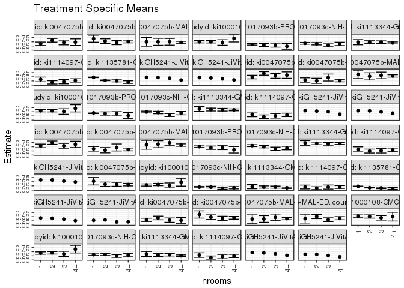

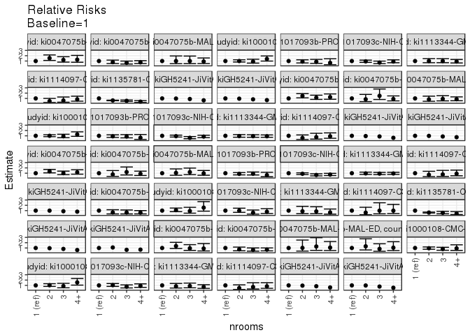

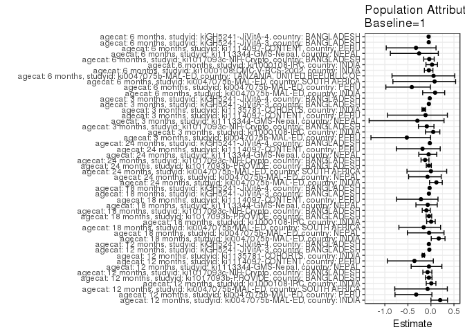

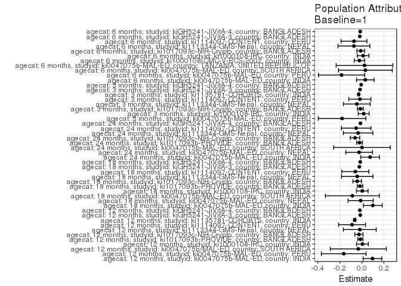

## Results Table

### Parameter: TSM

| agecat | studyid | country | intervention_level | baseline_level | estimate | ci_lower | ci_upper |
| --- | --- | --- | --- | --- | --- | --- | --- |
| 3 months | ki0047075b-MAL-ED | PERU | 1 | NA | 0.5263158 | 0.3013903 | 0.7512413 |
| 3 months | ki0047075b-MAL-ED | PERU | 2 | NA | 0.3461538 | 0.2166095 | 0.4756982 |
| 3 months | ki0047075b-MAL-ED | PERU | 3 | NA | 0.3387097 | 0.2206880 | 0.4567314 |
| 3 months | ki0047075b-MAL-ED | PERU | 4+ | NA | 0.3237410 | 0.2458126 | 0.4016694 |
| 3 months | ki1000108-IRC | INDIA | 1 | NA | 0.3027027 | 0.2364182 | 0.3689872 |
| 3 months | ki1000108-IRC | INDIA | 2 | NA | 0.3294118 | 0.2586736 | 0.4001500 |
| 3 months | ki1000108-IRC | INDIA | 3 | NA | 0.2777778 | 0.1312858 | 0.4242698 |
| 3 months | ki1000108-IRC | INDIA | 4+ | NA | 0.4705882 | 0.2330280 | 0.7081485 |
| 3 months | ki1017093c-NIH-Crypto | BANGLADESH | 1 | NA | 0.1739130 | 0.1351614 | 0.2126647 |
| 3 months | ki1017093c-NIH-Crypto | BANGLADESH | 2 | NA | 0.1727749 | 0.1191248 | 0.2264249 |
| 3 months | ki1017093c-NIH-Crypto | BANGLADESH | 3 | NA | 0.1057692 | 0.0466236 | 0.1649148 |
| 3 months | ki1017093c-NIH-Crypto | BANGLADESH | 4+ | NA | 0.1368421 | 0.0676864 | 0.2059978 |
| 3 months | ki1113344-GMS-Nepal | NEPAL | 1 | NA | 0.2051282 | 0.0782919 | 0.3319645 |
| 3 months | ki1113344-GMS-Nepal | NEPAL | 2 | NA | 0.1796875 | 0.1131206 | 0.2462544 |
| 3 months | ki1113344-GMS-Nepal | NEPAL | 3 | NA | 0.1744966 | 0.1135044 | 0.2354889 |
| 3 months | ki1113344-GMS-Nepal | NEPAL | 4+ | NA | 0.1335740 | 0.0934780 | 0.1736700 |
| 3 months | ki1114097-CONTENT | PERU | 1 | NA | 0.1818182 | 0.0675888 | 0.2960475 |
| 3 months | ki1114097-CONTENT | PERU | 2 | NA | 0.1111111 | 0.0270943 | 0.1951279 |
| 3 months | ki1114097-CONTENT | PERU | 3 | NA | 0.1794872 | 0.0587649 | 0.3002095 |
| 3 months | ki1114097-CONTENT | PERU | 4+ | NA | 0.1794872 | 0.0941236 | 0.2648507 |
| 3 months | ki1135781-COHORTS | INDIA | 1 | NA | 0.2200999 | 0.2061783 | 0.2340215 |
| 3 months | ki1135781-COHORTS | INDIA | 2 | NA | 0.1379081 | 0.1204631 | 0.1553531 |
| 3 months | ki1135781-COHORTS | INDIA | 3 | NA | 0.1276596 | 0.0799527 | 0.1753664 |
| 3 months | ki1135781-COHORTS | INDIA | 4+ | NA | 0.0990099 | 0.0407555 | 0.1572643 |
| 3 months | kiGH5241-JiVitA-3 | BANGLADESH | 1 | NA | 0.4214496 | NA | NA |
| 3 months | kiGH5241-JiVitA-3 | BANGLADESH | 2 | NA | 0.4058600 | NA | NA |
| 3 months | kiGH5241-JiVitA-3 | BANGLADESH | 3 | NA | 0.3482280 | NA | NA |
| 3 months | kiGH5241-JiVitA-3 | BANGLADESH | 4+ | NA | 0.2615101 | NA | NA |
| 3 months | kiGH5241-JiVitA-4 | BANGLADESH | 1 | NA | 0.2805755 | NA | NA |
| 3 months | kiGH5241-JiVitA-4 | BANGLADESH | 2 | NA | 0.3079585 | NA | NA |

[output cut: 162 more lines]

### Parameter: E(Y)

| agecat | studyid | country | intervention_level | baseline_level | estimate | ci_lower | ci_upper |
| --- | --- | --- | --- | --- | --- | --- | --- |
| 3 months | ki0047075b-MAL-ED | PERU | NA | NA | 0.3455882 | 0.2889684 | 0.4022081 |
| 3 months | ki1000108-IRC | INDIA | NA | NA | 0.3186275 | 0.2733601 | 0.3638948 |
| 3 months | ki1017093c-NIH-Crypto | BANGLADESH | NA | NA | 0.1596306 | 0.1335394 | 0.1857218 |
| 3 months | ki1113344-GMS-Nepal | NEPAL | NA | NA | 0.1585160 | 0.1290957 | 0.1879363 |
| 3 months | ki1114097-CONTENT | PERU | NA | NA | 0.1627907 | 0.1133285 | 0.2122529 |
| 3 months | ki1135781-COHORTS | INDIA | NA | NA | 0.1906412 | 0.1799566 | 0.2013259 |
| 3 months | kiGH5241-JiVitA-3 | BANGLADESH | NA | NA | 0.4035206 | NA | NA |
| 3 months | kiGH5241-JiVitA-4 | BANGLADESH | NA | NA | 0.2735931 | NA | NA |
| 6 months | ki0047075b-MAL-ED | INDIA | NA | NA | 0.3404255 | 0.2797123 | 0.4011387 |
| 6 months | ki0047075b-MAL-ED | PERU | NA | NA | 0.4464945 | 0.3871971 | 0.5057918 |
| 6 months | ki0047075b-MAL-ED | SOUTH AFRICA | NA | NA | 0.3882353 | 0.3283016 | 0.4481690 |
| 6 months | ki0047075b-MAL-ED | TANZANIA, UNITED REPUBLIC OF | NA | NA | 0.4080000 | 0.3469565 | 0.4690435 |
| 6 months | ki1000108-CMC-V-BCS-2002 | INDIA | NA | NA | 0.5122616 | 0.4610525 | 0.5634707 |
| 6 months | ki1000108-IRC | INDIA | NA | NA | 0.4261084 | 0.3779474 | 0.4742694 |
| 6 months | ki1017093c-NIH-Crypto | BANGLADESH | NA | NA | 0.3070652 | 0.2737175 | 0.3404129 |
| 6 months | ki1113344-GMS-Nepal | NEPAL | NA | NA | 0.2857143 | 0.2484972 | 0.3229313 |
| 6 months | ki1114097-CONTENT | PERU | NA | NA | 0.2232558 | 0.1674626 | 0.2790491 |
| 6 months | kiGH5241-JiVitA-3 | BANGLADESH | NA | NA | 0.4255630 | NA | NA |
| 6 months | kiGH5241-JiVitA-4 | BANGLADESH | NA | NA | 0.3273961 | NA | NA |
| 12 months | ki0047075b-MAL-ED | INDIA | NA | NA | 0.4765957 | 0.4126025 | 0.5405890 |
| 12 months | ki0047075b-MAL-ED | PERU | NA | NA | 0.5185185 | 0.4588090 | 0.5782281 |
| 12 months | ki0047075b-MAL-ED | SOUTH AFRICA | NA | NA | 0.4666667 | 0.4053139 | 0.5280194 |
| 12 months | ki1000108-IRC | INDIA | NA | NA | 0.5098522 | 0.4611660 | 0.5585385 |
| 12 months | ki1017093b-PROVIDE | BANGLADESH | NA | NA | 0.3316913 | 0.2942672 | 0.3691154 |
| 12 months | ki1017093c-NIH-Crypto | BANGLADESH | NA | NA | 0.3799726 | 0.3447141 | 0.4152311 |
| 12 months | ki1113344-GMS-Nepal | NEPAL | NA | NA | 0.4553265 | 0.4148326 | 0.4958204 |
| 12 months | ki1114097-CONTENT | PERU | NA | NA | 0.2511628 | 0.1930579 | 0.3092677 |
| 12 months | ki1135781-COHORTS | INDIA | NA | NA | 0.4000398 | 0.3864890 | 0.4135907 |
| 12 months | kiGH5241-JiVitA-3 | BANGLADESH | NA | NA | 0.4517864 | NA | NA |
| 12 months | kiGH5241-JiVitA-4 | BANGLADESH | NA | NA | 0.4341085 | NA | NA |
| 18 months | ki0047075b-MAL-ED | INDIA | NA | NA | 0.5807860 | 0.5167379 | 0.6448342 |
| 18 months | ki0047075b-MAL-ED | NEPAL | NA | NA | 0.2943723 | 0.2354716 | 0.3532730 |
| 18 months | ki0047075b-MAL-ED | SOUTH AFRICA | NA | NA | 0.5555556 | 0.4940827 | 0.6170285 |
| 18 months | ki1000108-IRC | INDIA | NA | NA | 0.5651106 | 0.5168890 | 0.6133321 |
| 18 months | ki1017093b-PROVIDE | BANGLADESH | NA | NA | 0.4172185 | 0.3778614 | 0.4565757 |
| 18 months | ki1017093c-NIH-Crypto | BANGLADESH | NA | NA | 0.4433566 | 0.4069178 | 0.4797954 |
| 18 months | ki1113344-GMS-Nepal | NEPAL | NA | NA | 0.6236934 | 0.5840266 | 0.6633602 |
| 18 months | ki1114097-CONTENT | PERU | NA | NA | 0.2803738 | 0.2200512 | 0.3406965 |
| 18 months | kiGH5241-JiVitA-3 | BANGLADESH | NA | NA | 0.5436177 | NA | NA |
| 18 months | kiGH5241-JiVitA-4 | BANGLADESH | NA | NA | 0.5477753 | NA | NA |
| 24 months | ki0047075b-MAL-ED | INDIA | NA | NA | 0.6228070 | 0.5597558 | 0.6858583 |
| 24 months | ki0047075b-MAL-ED | NEPAL | NA | NA | 0.3493450 | 0.2874603 | 0.4112297 |
| 24 months | ki0047075b-MAL-ED | SOUTH AFRICA | NA | NA | 0.6157025 | 0.5542897 | 0.6771153 |
| 24 months | ki1017093b-PROVIDE | BANGLADESH | NA | NA | 0.4810997 | 0.4404722 | 0.5217271 |
| 24 months | ki1017093c-NIH-Crypto | BANGLADESH | NA | NA | 0.5015773 | 0.4626267 | 0.5405279 |
| 24 months | ki1113344-GMS-Nepal | NEPAL | NA | NA | 0.6901408 | 0.6520774 | 0.7282042 |
| 24 months | ki1114097-CONTENT | PERU | NA | NA | 0.2893401 | 0.2258574 | 0.3528228 |
| 24 months | kiGH5241-JiVitA-4 | BANGLADESH | NA | NA | 0.5949791 | NA | NA |

### Parameter: RR

| agecat | studyid | country | intervention_level | baseline_level | estimate | ci_lower | ci_upper |
| --- | --- | --- | --- | --- | --- | --- | --- |
| 3 months | ki0047075b-MAL-ED | PERU | 1 | 1 | 1.0000000 | 1.0000000 | 1.0000000 |
| 3 months | ki0047075b-MAL-ED | PERU | 2 | 1 | 0.6576923 | 0.3726646 | 1.1607198 |
| 3 months | ki0047075b-MAL-ED | PERU | 3 | 1 | 0.6435484 | 0.3707732 | 1.1170023 |
| 3 months | ki0047075b-MAL-ED | PERU | 4+ | 1 | 0.6151079 | 0.3766478 | 1.0045399 |
| 3 months | ki1000108-IRC | INDIA | 1 | 1 | 1.0000000 | 1.0000000 | 1.0000000 |
| 3 months | ki1000108-IRC | INDIA | 2 | 1 | 1.0882353 | 0.8008023 | 1.4788371 |
| 3 months | ki1000108-IRC | INDIA | 3 | 1 | 0.9176587 | 0.5184272 | 1.6243314 |
| 3 months | ki1000108-IRC | INDIA | 4+ | 1 | 1.5546218 | 0.8967031 | 2.6952612 |
| 3 months | ki1017093c-NIH-Crypto | BANGLADESH | 1 | 1 | 1.0000000 | 1.0000000 | 1.0000000 |
| 3 months | ki1017093c-NIH-Crypto | BANGLADESH | 2 | 1 | 0.9934555 | 0.6778969 | 1.4559054 |
| 3 months | ki1017093c-NIH-Crypto | BANGLADESH | 3 | 1 | 0.6081731 | 0.3331209 | 1.1103310 |
| 3 months | ki1017093c-NIH-Crypto | BANGLADESH | 4+ | 1 | 0.7868421 | 0.4529207 | 1.3669512 |
| 3 months | ki1113344-GMS-Nepal | NEPAL | 1 | 1 | 1.0000000 | 1.0000000 | 1.0000000 |
| 3 months | ki1113344-GMS-Nepal | NEPAL | 2 | 1 | 0.8759766 | 0.4260380 | 1.8010950 |
| 3 months | ki1113344-GMS-Nepal | NEPAL | 3 | 1 | 0.8506711 | 0.4181095 | 1.7307462 |
| 3 months | ki1113344-GMS-Nepal | NEPAL | 4+ | 1 | 0.6511733 | 0.3274831 | 1.2948045 |
| 3 months | ki1114097-CONTENT | PERU | 1 | 1 | 1.0000000 | 1.0000000 | 1.0000000 |
| 3 months | ki1114097-CONTENT | PERU | 2 | 1 | 0.6111111 | 0.2286479 | 1.6333269 |
| 3 months | ki1114097-CONTENT | PERU | 3 | 1 | 0.9871795 | 0.3932608 | 2.4780588 |
| 3 months | ki1114097-CONTENT | PERU | 4+ | 1 | 0.9871795 | 0.4489344 | 2.1707479 |
| 3 months | ki1135781-COHORTS | INDIA | 1 | 1 | 1.0000000 | 1.0000000 | 1.0000000 |
| 3 months | ki1135781-COHORTS | INDIA | 2 | 1 | 0.6265703 | 0.5439359 | 0.7217584 |
| 3 months | ki1135781-COHORTS | INDIA | 3 | 1 | 0.5800074 | 0.3970341 | 0.8473039 |
| 3 months | ki1135781-COHORTS | INDIA | 4+ | 1 | 0.4498407 | 0.2489207 | 0.8129363 |
| 3 months | kiGH5241-JiVitA-3 | BANGLADESH | 1 | 1 | 1.0000000 | NA | NA |
| 3 months | kiGH5241-JiVitA-3 | BANGLADESH | 2 | 1 | 0.9630097 | NA | NA |
| 3 months | kiGH5241-JiVitA-3 | BANGLADESH | 3 | 1 | 0.8262627 | NA | NA |
| 3 months | kiGH5241-JiVitA-3 | BANGLADESH | 4+ | 1 | 0.6205016 | NA | NA |
| 3 months | kiGH5241-JiVitA-4 | BANGLADESH | 1 | 1 | 1.0000000 | NA | NA |
| 3 months | kiGH5241-JiVitA-4 | BANGLADESH | 2 | 1 | 1.0975956 | NA | NA |

[output cut: 162 more lines]

### Parameter: PAR

| agecat | studyid | country | intervention_level | baseline_level | estimate | ci_lower | ci_upper |
| --- | --- | --- | --- | --- | --- | --- | --- |
| 3 months | ki0047075b-MAL-ED | PERU | 1 | NA | -0.1807276 | -0.3968973 | 0.0354422 |
| 3 months | ki1000108-IRC | INDIA | 1 | NA | 0.0159247 | -0.0336569 | 0.0655064 |
| 3 months | ki1017093c-NIH-Crypto | BANGLADESH | 1 | NA | -0.0142824 | -0.0411959 | 0.0126310 |
| 3 months | ki1113344-GMS-Nepal | NEPAL | 1 | NA | -0.0466122 | -0.1684192 | 0.0751948 |
| 3 months | ki1114097-CONTENT | PERU | 1 | NA | -0.0190275 | -0.1197952 | 0.0817402 |
| 3 months | ki1135781-COHORTS | INDIA | 1 | NA | -0.0294587 | -0.0368045 | -0.0221128 |
| 3 months | kiGH5241-JiVitA-3 | BANGLADESH | 1 | NA | -0.0179290 | NA | NA |
| 3 months | kiGH5241-JiVitA-4 | BANGLADESH | 1 | NA | -0.0069825 | NA | NA |
| 6 months | ki0047075b-MAL-ED | INDIA | 1 | NA | 0.0309017 | -0.0496250 | 0.1114284 |
| 6 months | ki0047075b-MAL-ED | PERU | 1 | NA | -0.1850845 | -0.3951187 | 0.0249498 |
| 6 months | ki0047075b-MAL-ED | SOUTH AFRICA | 1 | NA | 0.0310924 | -0.2136383 | 0.2758232 |
| 6 months | ki0047075b-MAL-ED | TANZANIA, UNITED REPUBLIC OF | 1 | NA | 0.0233846 | -0.2347709 | 0.2815402 |
| 6 months | ki1000108-CMC-V-BCS-2002 | INDIA | 1 | NA | -0.0230920 | -0.0704203 | 0.0242364 |
| 6 months | ki1000108-IRC | INDIA | 1 | NA | 0.0108078 | -0.0423233 | 0.0639390 |
| 6 months | ki1017093c-NIH-Crypto | BANGLADESH | 1 | NA | -0.0111166 | -0.0459755 | 0.0237423 |
| 6 months | ki1113344-GMS-Nepal | NEPAL | 1 | NA | -0.0732601 | -0.2180612 | 0.0715411 |
| 6 months | ki1114097-CONTENT | PERU | 1 | NA | -0.0721987 | -0.1900894 | 0.0456919 |
| 6 months | kiGH5241-JiVitA-3 | BANGLADESH | 1 | NA | -0.0199942 | NA | NA |
| 6 months | kiGH5241-JiVitA-4 | BANGLADESH | 1 | NA | -0.0163097 | NA | NA |
| 12 months | ki0047075b-MAL-ED | INDIA | 1 | NA | 0.0956434 | 0.0108903 | 0.1803964 |
| 12 months | ki0047075b-MAL-ED | PERU | 1 | NA | -0.1656920 | -0.3687716 | 0.0373876 |
| 12 months | ki0047075b-MAL-ED | SOUTH AFRICA | 1 | NA | -0.0333333 | -0.2884211 | 0.2217545 |
| 12 months | ki1000108-IRC | INDIA | 1 | NA | 0.0044174 | -0.0490616 | 0.0578965 |
| 12 months | ki1017093b-PROVIDE | BANGLADESH | 1 | NA | -0.0147290 | -0.0382131 | 0.0087551 |
| 12 months | ki1017093c-NIH-Crypto | BANGLADESH | 1 | NA | -0.0275419 | -0.0646822 | 0.0095985 |
| 12 months | ki1113344-GMS-Nepal | NEPAL | 1 | NA | -0.0196735 | -0.1691139 | 0.1297669 |
| 12 months | ki1114097-CONTENT | PERU | 1 | NA | -0.0897463 | -0.2122938 | 0.0328012 |
| 12 months | ki1135781-COHORTS | INDIA | 1 | NA | -0.0657262 | -0.0755454 | -0.0559070 |
| 12 months | kiGH5241-JiVitA-3 | BANGLADESH | 1 | NA | -0.0155888 | NA | NA |
| 12 months | kiGH5241-JiVitA-4 | BANGLADESH | 1 | NA | -0.0193661 | NA | NA |
| 18 months | ki0047075b-MAL-ED | INDIA | 1 | NA | 0.0988583 | 0.0134467 | 0.1842699 |
| 18 months | ki0047075b-MAL-ED | NEPAL | 1 | NA | -0.0117502 | -0.1261999 | 0.1026996 |
| 18 months | ki0047075b-MAL-ED | SOUTH AFRICA | 1 | NA | -0.0873016 | -0.3322505 | 0.1576473 |
| 18 months | ki1000108-IRC | INDIA | 1 | NA | 0.0029484 | -0.0498824 | 0.0557792 |
| 18 months | ki1017093b-PROVIDE | BANGLADESH | 1 | NA | -0.0173609 | -0.0424072 | 0.0076854 |
| 18 months | ki1017093c-NIH-Crypto | BANGLADESH | 1 | NA | -0.0432902 | -0.0819077 | -0.0046727 |
| 18 months | ki1113344-GMS-Nepal | NEPAL | 1 | NA | -0.0429733 | -0.1862238 | 0.1002772 |
| 18 months | ki1114097-CONTENT | PERU | 1 | NA | -0.0605353 | -0.1839982 | 0.0629277 |
| 18 months | kiGH5241-JiVitA-3 | BANGLADESH | 1 | NA | -0.0235141 | NA | NA |
| 18 months | kiGH5241-JiVitA-4 | BANGLADESH | 1 | NA | -0.0154850 | NA | NA |
| 24 months | ki0047075b-MAL-ED | INDIA | 1 | NA | 0.0740265 | -0.0110971 | 0.1591501 |
| 24 months | ki0047075b-MAL-ED | NEPAL | 1 | NA | -0.0256550 | -0.1471926 | 0.0958825 |
| 24 months | ki0047075b-MAL-ED | SOUTH AFRICA | 1 | NA | 0.0003179 | -0.2574736 | 0.2581093 |
| 24 months | ki1017093b-PROVIDE | BANGLADESH | 1 | NA | -0.0213394 | -0.0476280 | 0.0049493 |
| 24 months | ki1017093c-NIH-Crypto | BANGLADESH | 1 | NA | -0.0628826 | -0.1056501 | -0.0201152 |
| 24 months | ki1113344-GMS-Nepal | NEPAL | 1 | NA | -0.0348592 | -0.1687558 | 0.0990375 |
| 24 months | ki1114097-CONTENT | PERU | 1 | NA | -0.0527652 | -0.1872130 | 0.0816827 |
| 24 months | kiGH5241-JiVitA-4 | BANGLADESH | 1 | NA | -0.0139595 | NA | NA |

### Parameter: PAF

| agecat | studyid | country | intervention_level | baseline_level | estimate | ci_lower | ci_upper |
| --- | --- | --- | --- | --- | --- | --- | --- |
| 3 months | ki0047075b-MAL-ED | PERU | 1 | NA | -0.5229563 | -1.3018517 | -0.0076218 |
| 3 months | ki1000108-IRC | INDIA | 1 | NA | 0.0499792 | -0.1190792 | 0.1934981 |
| 3 months | ki1017093c-NIH-Crypto | BANGLADESH | 1 | NA | -0.0894718 | -0.2713810 | 0.0664098 |
| 3 months | ki1113344-GMS-Nepal | NEPAL | 1 | NA | -0.2940535 | -1.3415674 | 0.2848490 |
| 3 months | ki1114097-CONTENT | PERU | 1 | NA | -0.1168831 | -0.9430289 | 0.3579983 |
| 3 months | ki1135781-COHORTS | INDIA | 1 | NA | -0.1545241 | -0.1932452 | -0.1170594 |
| 3 months | kiGH5241-JiVitA-3 | BANGLADESH | 1 | NA | -0.0444314 | NA | NA |
| 3 months | kiGH5241-JiVitA-4 | BANGLADESH | 1 | NA | -0.0255214 | NA | NA |
| 6 months | ki0047075b-MAL-ED | INDIA | 1 | NA | 0.0907738 | -0.1793511 | 0.2990279 |
| 6 months | ki0047075b-MAL-ED | PERU | 1 | NA | -0.4145281 | -0.9783383 | -0.0113991 |
| 6 months | ki0047075b-MAL-ED | SOUTH AFRICA | 1 | NA | 0.0800866 | -0.8253877 | 0.5364049 |
| 6 months | ki0047075b-MAL-ED | TANZANIA, UNITED REPUBLIC OF | 1 | NA | 0.0573152 | -0.8444840 | 0.5182097 |
| 6 months | ki1000108-CMC-V-BCS-2002 | INDIA | 1 | NA | -0.0450784 | -0.1418199 | 0.0434665 |
| 6 months | ki1000108-IRC | INDIA | 1 | NA | 0.0253640 | -0.1076693 | 0.1424198 |
| 6 months | ki1017093c-NIH-Crypto | BANGLADESH | 1 | NA | -0.0362027 | -0.1561715 | 0.0713176 |
| 6 months | ki1113344-GMS-Nepal | NEPAL | 1 | NA | -0.2564103 | -0.8806881 | 0.1606441 |
| 6 months | ki1114097-CONTENT | PERU | 1 | NA | -0.3233902 | -0.9701145 | 0.1110357 |
| 6 months | kiGH5241-JiVitA-3 | BANGLADESH | 1 | NA | -0.0469830 | NA | NA |
| 6 months | kiGH5241-JiVitA-4 | BANGLADESH | 1 | NA | -0.0498164 | NA | NA |
| 12 months | ki0047075b-MAL-ED | INDIA | 1 | NA | 0.2006803 | 0.0003566 | 0.3608600 |
| 12 months | ki0047075b-MAL-ED | PERU | 1 | NA | -0.3195489 | -0.7798017 | 0.0216836 |
| 12 months | ki0047075b-MAL-ED | SOUTH AFRICA | 1 | NA | -0.0714286 | -0.7846714 | 0.3567672 |
| 12 months | ki1000108-IRC | INDIA | 1 | NA | 0.0086641 | -0.1019812 | 0.1082001 |
| 12 months | ki1017093b-PROVIDE | BANGLADESH | 1 | NA | -0.0444058 | -0.1176689 | 0.0240549 |
| 12 months | ki1017093c-NIH-Crypto | BANGLADESH | 1 | NA | -0.0724839 | -0.1749010 | 0.0210054 |
| 12 months | ki1113344-GMS-Nepal | NEPAL | 1 | NA | -0.0432075 | -0.4289324 | 0.2383950 |
| 12 months | ki1114097-CONTENT | PERU | 1 | NA | -0.3573232 | -0.9435678 | 0.0520905 |
| 12 months | ki1135781-COHORTS | INDIA | 1 | NA | -0.1642992 | -0.1894590 | -0.1396715 |
| 12 months | kiGH5241-JiVitA-3 | BANGLADESH | 1 | NA | -0.0345048 | NA | NA |
| 12 months | kiGH5241-JiVitA-4 | BANGLADESH | 1 | NA | -0.0446113 | NA | NA |
| 18 months | ki0047075b-MAL-ED | INDIA | 1 | NA | 0.1702147 | 0.0074653 | 0.3062775 |
| 18 months | ki0047075b-MAL-ED | NEPAL | 1 | NA | -0.0399160 | -0.5113431 | 0.2844608 |
| 18 months | ki0047075b-MAL-ED | SOUTH AFRICA | 1 | NA | -0.1571429 | -0.6947682 | 0.2099335 |
| 18 months | ki1000108-IRC | INDIA | 1 | NA | 0.0052174 | -0.0928058 | 0.0944480 |
| 18 months | ki1017093b-PROVIDE | BANGLADESH | 1 | NA | -0.0416110 | -0.1034730 | 0.0167829 |
| 18 months | ki1017093c-NIH-Crypto | BANGLADESH | 1 | NA | -0.0976420 | -0.1885929 | -0.0136507 |
| 18 months | ki1113344-GMS-Nepal | NEPAL | 1 | NA | -0.0689013 | -0.3252571 | 0.1378654 |
| 18 months | ki1114097-CONTENT | PERU | 1 | NA | -0.2159091 | -0.7463785 | 0.1534281 |
| 18 months | kiGH5241-JiVitA-3 | BANGLADESH | 1 | NA | -0.0432549 | NA | NA |
| 18 months | kiGH5241-JiVitA-4 | BANGLADESH | 1 | NA | -0.0282689 | NA | NA |
| 24 months | ki0047075b-MAL-ED | INDIA | 1 | NA | 0.1188595 | -0.0301658 | 0.2463266 |
| 24 months | ki0047075b-MAL-ED | NEPAL | 1 | NA | -0.0734375 | -0.4843854 | 0.2237406 |
| 24 months | ki0047075b-MAL-ED | SOUTH AFRICA | 1 | NA | 0.0005163 | -0.5195203 | 0.3425769 |
| 24 months | ki1017093b-PROVIDE | BANGLADESH | 1 | NA | -0.0443554 | -0.1005796 | 0.0089965 |
| 24 months | ki1017093c-NIH-Crypto | BANGLADESH | 1 | NA | -0.1253698 | -0.2147046 | -0.0426051 |
| 24 months | ki1113344-GMS-Nepal | NEPAL | 1 | NA | -0.0505102 | -0.2636837 | 0.1267026 |
| 24 months | ki1114097-CONTENT | PERU | 1 | NA | -0.1823638 | -0.7514830 | 0.2018283 |
| 24 months | kiGH5241-JiVitA-4 | BANGLADESH | 1 | NA | -0.0234621 | NA | NA |